# **Projet: SEGMENTATION DES CLIENTS ET DES COMPTES**

### **Réalisation:Haral Valcourt**

### **Présentation du projet**

Ce projet répond à une demande formulée par la Direction du Marketing et des Relations Publiques de la Banque Nationale de Crédit (BNC). Son objectif est de mettre à la disposition de cette Direction une interface permettant la génération des rapports statistiques relatifs à la segmentation de la clientèle en fonction de différents critères ainsi qu’un tableau de bord. L’interface de génération des rapports est connectée directement à l’environnement de production AS400/DB2. Pour ce qui a trait au tableau de bord les données sont périodiquement extraites de l'environnement de production, traitées et modélisées dans une Base de données SQL Server puis visualisées à travers Microsoft Excel.

### **La demande formulée par la Direction du Marketing**

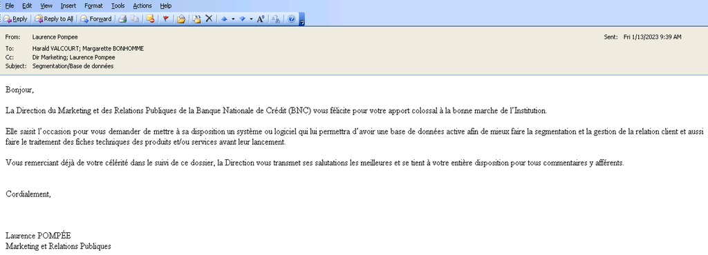

### **L'avis de satisfaction exprimé par la Direction du Marketing**

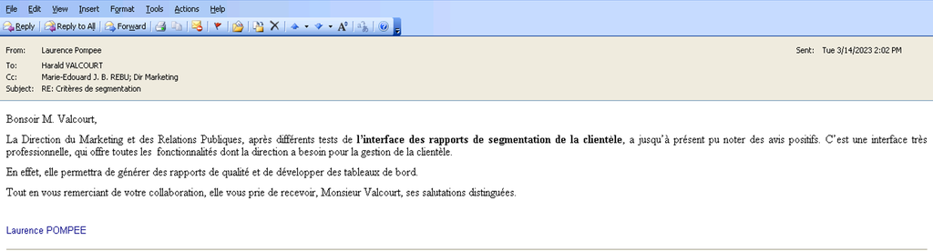

### **Outils technologiques**

Les outils suivants sont utilisés pour l'implémentation du projet:

- Bases de Données: AS400/DB2 et Microsoft SQL Server
- les langages : SQL,Visual Basic 6.0, Visual Basic for Applications
- Outil d'extraction de données: Microsoft Crystal SQL Designer
- Outil d'analyse et de visualisation: Microsoft Excel,Seaborn et Matplotlib

### **Jeu de données**

Le jeu de données est une extraction des données du système de production AS400/ DB2. L’extraction est effectuée à partir d’une requête SQL à travers l’outil Crystal SQL Designer de Microsoft. La requête est basée sur plusieurs fichiers de la Base de données DB2 puis le résultat est exporté au format Excel.

[figure not shown]

### **Compréhension du jeu de données**

- DMACCT: le numéro du compte du client
- DMTYP : le type de compte
- DMBRCH :la Branch d'ouverture du compte
- CUSEX : le sexe du client
- CUBDTE: la date de naissance du client
- DMCBAL: la balance du compte
- DMSTAT: le statut du compte
- CUNBR: le numero du client

### **Les étapes de l'implémentation**

Les étapes de l'implémentation sont les suivantes:

- Importation des librairies
- Création de la Base de Données
- Importation des données dans MS SQL Server
- Connexion à la Base de Données
- Modélisation des données
- Exploration des données
- Connexion de MS Excel avec MS SQL Server à travers Power Query
- Traitement des données dans MS Excel avec POWER QUERY
- Analyse et Visualisation des données dans MS Excel avec PivotTable et PivotChart
- Création du tableau de bord avec MS Excel

### **Importation des librairies**

```python
import pyodbc
import pandas as pd
import pandasql as ps
import numpy as np
import matplotlib.pyplot as plt
import seaborn as sns
import os
```

```python
sns.set_context("paper", font_scale=0.9)
from warnings import filterwarnings
filterwarnings('ignore')
```

### **Création de la Base de Données**

[figure not shown]

### **Importation des données**

[figure not shown]

### **Connexion à la Base de Données**

```python
DB = {'servername': 'DESKTOP-RUJ1AK0', 'database': 'BANQUE'}
conn = pyodbc.connect('DRIVER={SQL Server};   SERVER=' + DB['servername'] + ';  DATABASE=' + DB['database']  )
cur= conn.cursor()
print("Connexion établie")
```

```
Connexion établie
```

```python
query = "SELECT TOP 3 * FROM COMPTE;"
df = pd.read_sql(query, conn)
df
```

|  | NOCOMPTE | TYPE | BRANCH | SEXE | DATENAIS | BALANCE | STATUT | NUMERO |
| --- | --- | --- | --- | --- | --- | --- | --- | --- |
| 0 | 4141000226 | 6 | 1 | M | 1954-01-03 | 0.02 | 1 | 1028649 |
| 1 | 1610053064 | 3 | 5 | M | 1954-01-03 | 0.12 | 1 | 5253 |
| 2 | 410044628 | 3 | 4 | M | 1954-01-03 | 0.13 | 5 | 42087 |

### **Renommage des colonnes**

```python
query="EXEC sp_RENAME 'compte.DMACCT' , 'NOCOMPTE', 'COLUMN'";
cur.execute(query)
print('Modification éffectuée')
```

```
Modification éffectuée
```

```python
query="EXEC sp_RENAME 'compte.DMTYP' , 'TYPE', 'COLUMN'";
cur.execute(query)
print('Modification éffectuée')
```

```
Modification éffectuée
```

```python
query="EXEC sp_RENAME 'compte.CUSEX' , 'SEXE', 'COLUMN'";
cur.execute(query)
print('Modification éffectuée')
```

```
Modification éffectuée
```

```python
query="EXEC sp_RENAME 'compte.CUBDTE' , 'DATENAIS', 'COLUMN'  ";
cur.execute(query)
print('Modification éffectuée')
```

```
Modification éffectuée
```

```python
query="EXEC sp_RENAME 'compte.DMCBAL' , 'BALANCE', 'COLUMN'";
cur.execute(query)
print('Modification éffectuée')
```

```
Modification éffectuée
```

```python
query="EXEC sp_RENAME 'compte.DMSTAT' , 'STATUT', 'COLUMN'";
cur.execute(query)
print('Modification éffectuée')
```

```
Modification éffectuée
```

```python
query="EXEC sp_RENAME 'compte.CUNBR' , 'NUMERO', 'COLUMN'";
cur.execute(query)
print('Modification éffectuée')
```

```
Modification éffectuée
```

```python
query="EXEC sp_RENAME 'compte.DMBRCH' , 'BRANCH', 'COLUMN'";
cur.execute(query)
print('Modification éffectuée')
```

```
Modification éffectuée
```

### **Affichage du nom des colonnes et des types de données**

```python
query = "select column_name,data_type from INFORMATION_SCHEMA.COLUMNS NomColonnes where TABLE_NAME='COMPTE';"
df1 = pd.read_sql(query, conn)
df1
```

|  | column_name | data_type |
| --- | --- | --- |
| 0 | NOCOMPTE | nvarchar |
| 1 | TYPE | int |
| 2 | BRANCH | int |
| 3 | SEXE | nvarchar |
| 4 | DATENAIS | date |
| 5 | BALANCE | float |
| 6 | STATUT | int |
| 7 | NUMERO | int |

### **Modélisation des données**

### **Ajout d'une colonne "TYPE_COMPTE" pour classifier les comptes**

```python
query="ALTER TABLE COMPTE ADD TYPE_COMPTE VARCHAR(25)";
cur.execute(query)
print('Nouvelle colonne ajoutée')
```

```
Nouvelle colonne ajoutée
```

### **Mettre à jour la colonne "TYPE_COMPTE"**

```python
query="""
UPDATE COMPTE SET TYPE_COMPTE =
			   CASE WHEN type=1 THEN 'Compte Epargne'
			        WHEN type=6 THEN 'Compte Courant'
			        WHEN type=5 THEN 'Compte de Prêt'
			        WHEN type=3 THEN 'Dépôt à terme'
			        ELSE 'Autres'
			   END
               commit
               """
cur.execute(query)
print('Mise à jour effectuée')
```

```
Mise à jour effectuée
```

```python
query = " select top 5 nocompte,type,type_compte from compte;"
df = pd.read_sql(query, conn)
df
```

|  | nocompte | type | type_compte |
| --- | --- | --- | --- |
| 0 | 4141000226 | 6 | Compte Courant |
| 1 | 1610053064 | 3 | Dépôt à terme |
| 2 | 410044628 | 3 | Dépôt à terme |
| 3 | 2110022595 | 1 | Compte Epargne |
| 4 | 2410015269 | 1 | Compte Epargne |

### **Ajout d'une colonne "SEXE_CLIENT" pour classifier le sexe**

```python
query="ALTER TABLE COMPTE ADD SEXE_CLIENT VARCHAR(10)";
cur.execute(query)
print('Nouvelle colonne ajoutée')
```

```
Nouvelle colonne ajoutée
```

### **Mettre à jour la colonne "SEXE_CLIENT"**

```python
query="""
UPDATE COMPTE SET SEXE_CLIENT =
			   CASE WHEN sexe ='M' THEN 'Homme'
			        WHEN sexe ='F' THEN 'Femme'
			        ELSE 'Autres'
			   END
               commit
               """
cur.execute(query)
print('Mise à jour éffectuée')
```

```
Mise à jour éffectuée
```

```python
query = " select top 5 nocompte, sexe ,sexe_client from compte;"
df1 = pd.read_sql(query, conn)
df1
```

|  | nocompte | sexe | sexe_client |
| --- | --- | --- | --- |
| 0 | 4141000226 | M | Homme |
| 1 | 1610053064 | M | Homme |
| 2 | 410044628 | M | Homme |
| 3 | 2110022595 | F | Femme |
| 4 | 2410015269 | F | Femme |

### **Ajout d'une colonne "STATUT_COMPTE" pour classifier le statut du compte**

```python
query="ALTER TABLE COMPTE ADD STATUT_COMPTE VARCHAR(10)";
cur.execute(query)
print('Nouvelle colonne ajoutée')
```

```
Nouvelle colonne ajoutée
```

### **Mettre à jour la colonne STATUT_COMPTE**

```python
query="""
UPDATE COMPTE SET STATUT_COMPTE =
			   CASE WHEN statut =1 THEN 'Ouvert'
			        WHEN statut =3 THEN 'No Débit'
                    WHEN statut =5 THEN 'Dormant'
			        WHEN statut =7 THEN 'Fermé'
			        ELSE 'Autres'
			   END
               commit
               """
cur.execute(query)
print('Mise à jour éffectuée')
```

```
Mise à jour éffectuée
```

```python
query = " select top 5 nocompte, statut ,statut_compte from compte;"
df1 = pd.read_sql(query, conn)
df1
```

|  | nocompte | statut | statut_compte |
| --- | --- | --- | --- |
| 0 | 4141000226 | 1 | Ouvert |
| 1 | 1610053064 | 1 | Ouvert |
| 2 | 410044628 | 5 | Dormant |
| 3 | 2110022595 | 1 | Ouvert |
| 4 | 2410015269 | 5 | Dormant |

### **Ajouter un colonne "ANNEE" pour stocker l'année de naissance des clients**

```python
query="ALTER TABLE COMPTE ADD ANNEE INT";
cur.execute(query)
print('Nouvelle colonne ajoutée')
```

```
Nouvelle colonne ajoutée
```

```python
query="UPDATE COMPTE SET ANNEE =YEAR(DATENAIS)"
cur.execute(query)
print('Mise à jour éffectuée')
```

```
Mise à jour éffectuée
```

```python
query = " select top 5 nocompte, statut ,statut_compte,annee from compte;"
df1 = pd.read_sql(query, conn)
df1
```

|  | nocompte | statut | statut_compte | annee |
| --- | --- | --- | --- | --- |
| 0 | 4141000226 | 1 | Ouvert | 1954 |
| 1 | 1610053064 | 1 | Ouvert | 1954 |
| 2 | 410044628 | 5 | Dormant | 1954 |
| 3 | 2110022595 | 1 | Ouvert | 1954 |
| 4 | 2410015269 | 5 | Dormant | 1954 |

### **Ajouter un colonne "MOIS" pour stocker le mois de naissance des clients**

```python
query="ALTER TABLE COMPTE ADD MOIS INT";
cur.execute(query)
print('Nouvelle colonne ajoutée')
```

```
Nouvelle colonne ajoutée
```

```python
query="UPDATE COMPTE SET MOIS =MONTH(DATENAIS)"
cur.execute(query)
print('Mise à jour éffectuée')
```

```
Mise à jour éffectuée
```

```python
query = " select top 5 nocompte, statut ,statut_compte,mois from compte;"
df1 = pd.read_sql(query, conn)
df1
```

|  | nocompte | statut | statut_compte | mois |
| --- | --- | --- | --- | --- |
| 0 | 4141000226 | 1 | Ouvert | 1 |
| 1 | 1610053064 | 1 | Ouvert | 1 |
| 2 | 410044628 | 5 | Dormant | 1 |
| 3 | 2110022595 | 1 | Ouvert | 1 |
| 4 | 2410015269 | 5 | Dormant | 1 |

### **Ajouter un colonne "JOUR" pour stocker le jour de naissance des clients**

```python
query="ALTER TABLE COMPTE ADD JOUR INT";
cur.execute(query)
print('Nouvelle colonne ajoutée')
```

```
Nouvelle colonne ajoutée
```

```python
query="UPDATE COMPTE SET JOUR =DAY(DATENAIS)"
cur.execute(query)
print('Mise à jour éffectuée')
```

```
Mise à jour éffectuée
```

```python
query = " select top 5 nocompte, statut ,statut_compte,jour from compte;"
df1 = pd.read_sql(query, conn)
df1
```

|  | nocompte | statut | statut_compte | jour |
| --- | --- | --- | --- | --- |
| 0 | 4141000226 | 1 | Ouvert | 3 |
| 1 | 1610053064 | 1 | Ouvert | 3 |
| 2 | 410044628 | 5 | Dormant | 3 |
| 3 | 2110022595 | 1 | Ouvert | 3 |
| 4 | 2410015269 | 5 | Dormant | 3 |

### **Ajouter une colonne "NOMMOIS" pour stocker le mois de naissance des clients**

```python
query="ALTER TABLE COMPTE ADD NOMMOIS VARCHAR(15)";
cur.execute(query)
print('Nouvelle colonne ajoutée')
```

```
Nouvelle colonne ajoutée
```

```python
query="UPDATE COMPTE SET NOMMOIS =DATENAME(mm,DATENAIS)"
cur.execute(query)
print('Mise à jour éffectuée')
```

```
Mise à jour éffectuée
```

### **Ajouter une colonne "NOMJOUR" pour stocker le jour de naissance des clients**

```python
query="ALTER TABLE COMPTE ADD NOMJOUR VARCHAR(15)";
cur.execute(query)
print('Nouvelle colonne ajoutée')
```

```
Nouvelle colonne ajoutée
```

```python
query="UPDATE COMPTE SET NOMJOUR =DATENAME(dw,DATENAIS)"
cur.execute(query)
print('Mise à jour éffectuée')
```

```
Mise à jour éffectuée
```

### **Ajouter une colonne "AGE" pour stocker l’âge des clients**

```python
query="ALTER TABLE COMPTE ADD AGE INT";
cur.execute(query)
print('Nouvelle colonne ajoutée')
```

```
Nouvelle colonne ajoutée
```

### **Mettre à jour l’âge des clients**

```python
query="UPDATE COMPTE SET AGE =YEAR(getdate())-YEAR(DATENAIS) "
cur.execute(query)
print('Mise à jour éffectuée')
```

```
Mise à jour éffectuée
```

### **Ajouter une colonne "RANG_AGE" pour classifier l’âge des clients**

```python
query="ALTER TABLE COMPTE ADD RANG_AGE VARCHAR(15)";
cur.execute(query)
print('Nouvelle colonne ajoutée')
```

```
Nouvelle colonne ajoutée
```

```python
query="""
UPDATE COMPTE SET RANG_AGE =
			   CASE WHEN age <30  THEN 'Moins que 30'
			        WHEN age between 30 and 50 THEN 'Entre 30 & 50'
                    WHEN age between 50 and 70 THEN 'Entre 50 & 70'
			        WHEN age >=70 THEN 'Plus que 70'
			        ELSE 'Autres'
			   END
               commit
               """
cur.execute(query)
print('Mise à jour éffectuée')
```

```
Mise à jour éffectuée
```

### **Ajouter une colonne "SUCC" pour classifier les branches**

```python
query="ALTER TABLE COMPTE ADD SUCC VARCHAR(15)";
cur.execute(query)
print('Nouvelle colonne ajoutée')
```

```
Nouvelle colonne ajoutée
```

### **Mettre à jour la colonne "SUCC"**

```python
query="""
UPDATE COMPTE SET SUCC =
			   CASE WHEN branch =1 THEN 'LGN'
			        WHEN branch =2 THEN 'GNV'
                    WHEN branch =3 THEN 'FTL'
			        WHEN branch =4 THEN 'CAY'
			        ELSE 'FDN'
			   END
               commit
               """
cur.execute(query)
print('Mise à jour éffectuée')
```

```
Mise à jour éffectuée
```

### **Ajouter une colonne "ZONE" pour la gestion des zônes géographiques**

```python
query="ALTER TABLE COMPTE ADD ZONE VARCHAR(15)";
cur.execute(query)
print('Nouvelle colonne ajoutée')
```

```
Nouvelle colonne ajoutée
```

### **Mettre à jour la colonne "ZONE"**

```python
query="""
UPDATE COMPTE SET ZONE =
			   CASE WHEN branch =1 THEN 'OUEST'
			        WHEN branch =2 THEN 'NORD'
                    WHEN branch =3 THEN 'NORD'
			        WHEN branch =4 THEN 'SUD'
			        ELSE 'EST'
			   END
               commit
               """
cur.execute(query)
print('Mise à jour éffectuée')
```

```
Mise à jour éffectuée
```

```python
query = " select * from compte;"
df1 = pd.read_sql(query, conn)
df1.head(3)
```

|  | NOCOMPTE | TYPE | BRANCH | SEXE | DATENAIS | BALANCE | STATUT | NUMERO | TYPE_COMPTE | SEXE_CLIENT | STATUT_COMPTE | ANNEE | MOIS | JOUR | NOMMOIS | NOMJOUR | AGE | RANG_AGE | SUCC | ZONE |
| --- | --- | --- | --- | --- | --- | --- | --- | --- | --- | --- | --- | --- | --- | --- | --- | --- | --- | --- | --- | --- |
| 0 | 4141000226 | 6 | 1 | M | 1954-01-03 | 0.02 | 1 | 1028649 | Compte Courant | Homme | Ouvert | 1954 | 1 | 3 | January | Sunday | 71 | Plus que 70 | LGN | OUEST |
| 1 | 1610053064 | 3 | 5 | M | 1954-01-03 | 0.12 | 1 | 5253 | Dépôt à terme | Homme | Ouvert | 1954 | 1 | 3 | January | Sunday | 71 | Plus que 70 | FDN | EST |
| 2 | 410044628 | 3 | 4 | M | 1954-01-03 | 0.13 | 5 | 42087 | Dépôt à terme | Homme | Dormant | 1954 | 1 | 3 | January | Sunday | 71 | Plus que 70 | CAY | SUD |

### **Exploration des données**

Dans cette partie du projet on répondra aux questions suivantes à partir de requête SQL:

### **Répartition des comptes par succursale**

```python
query = "SELECT SUCC,count(NOCOMPTE) as QUANTITE from COMPTE group by SUCC"
df = pd.read_sql(query, conn)
df
```

|  | SUCC | QUANTITE |
| --- | --- | --- |
| 0 | LGN | 11417 |
| 1 | FDN | 7423 |
| 2 | CAY | 3851 |
| 3 | GNV | 4143 |
| 4 | FTL | 10093 |

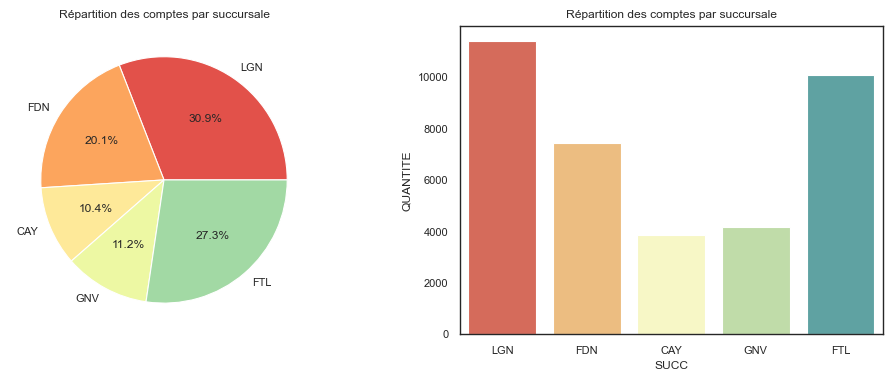

```python
sns.set_context("paper", font_scale=0.9)
plt.figure(figsize=(12,4))
colors = sns.color_palette("Spectral")
plt.subplot(1,2,1)
plt.pie(df['QUANTITE'], labels=df['SUCC'], autopct='%1.1f%%',colors = colors)
plt.title('Répartition des comptes par succursale')

plt.subplot(1,2,2)
sns.set_style("white")
sns.barplot(x=df["SUCC"],y=df["QUANTITE"],data=df,hue=df["SUCC"],palette="Spectral").set_title("Répartition des comptes par succursale");
plt.show()
```

### **Répartition des comptes par type**

```python
query = "SELECT TYPE_COMPTE,count(NOCOMPTE) as QUANTITE from COMPTE group by TYPE_COMPTE"
df = pd.read_sql(query, conn)
df
```

|  | TYPE_COMPTE | QUANTITE |
| --- | --- | --- |
| 0 | Compte Courant | 6299 |
| 1 | Compte de Prêt | 11435 |
| 2 | Dépôt à terme | 4890 |
| 3 | Compte Epargne | 14303 |

[figure not shown]

```python
plt.figure(figsize=(12,4))
colors = sns.color_palette("Spectral")
plt.subplot(1,2,1)
plt.pie(df['QUANTITE'], labels=df['TYPE_COMPTE'], autopct='%1.1f%%',colors = colors)
plt.title('Répartition des comptes par Succursale')

plt.subplot(1,2,2)
sns.set_style("white")
sns.barplot(x='TYPE_COMPTE',y='QUANTITE',data=df,hue="TYPE_COMPTE",palette="Spectral").set_title("Répartition des comptes par Succursale");
plt.show()
```

### **Répartition des comptes par Succursale et type**

```python
query = """
SELECT SUCC, TYPE_COMPTE, COUNT(NUMERO) QUANTITE
from COMPTE
group by SUCC,TYPE_COMPTE
ORDER BY SUCC
"""
df = pd.read_sql(query, conn)
df
```

|  | SUCC | TYPE_COMPTE | QUANTITE |
| --- | --- | --- | --- |
| 0 | CAY | Compte Epargne | 1550 |
| 1 | CAY | Compte de Prêt | 990 |
| 2 | CAY | Dépôt à terme | 40 |
| 3 | CAY | Compte Courant | 1271 |
| 4 | FDN | Compte Epargne | 1923 |
| 5 | FDN | Compte de Prêt | 2278 |
| 6 | FDN | Compte Courant | 669 |
| 7 | FDN | Dépôt à terme | 2553 |
| 8 | FTL | Compte de Prêt | 2518 |
| 9 | FTL | Dépôt à terme | 338 |
| 10 | FTL | Compte Epargne | 5945 |
| 11 | FTL | Compte Courant | 1292 |
| 12 | GNV | Compte Epargne | 1980 |
| 13 | GNV | Dépôt à terme | 1055 |
| 14 | GNV | Compte Courant | 148 |
| 15 | GNV | Compte de Prêt | 960 |
| 16 | LGN | Compte Courant | 2919 |
| 17 | LGN | Compte Epargne | 2905 |
| 18 | LGN | Compte de Prêt | 4689 |
| 19 | LGN | Dépôt à terme | 904 |

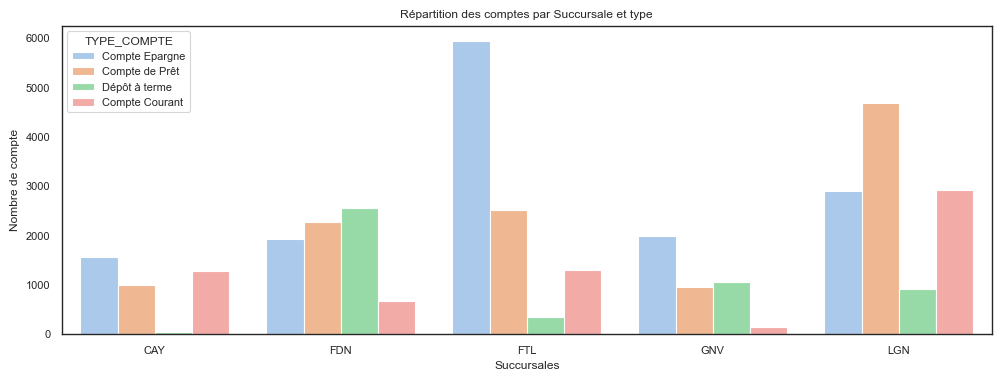

```python
plt.figure(figsize = (12,4))
sns.set_style("white")
sns.barplot(x=df.SUCC,y=df.QUANTITE,data=df,hue="TYPE_COMPTE",palette="pastel").set_title("Répartition des comptes par Succursale et type");
plt.xlabel("Succursales")
plt.ylabel("Nombre de compte")
```

### **Répartition de la balance des comptes par succursale et type**

```python
query = """
SELECT SUCC ,TYPE_COMPTE, CAST(SUM(BALANCE)/1000000 AS DECIMAL(10,2)) TOTAL_MILLION
from COMPTE
group by SUCC,TYPE_COMPTE
ORDER BY SUCC
"""
df = pd.read_sql(query, conn)
df
```

|  | SUCC | TYPE_COMPTE | TOTAL_MILLION |
| --- | --- | --- | --- |
| 0 | CAY | Compte Epargne | 120.87 |
| 1 | CAY | Compte de Prêt | 28.48 |
| 2 | CAY | Dépôt à terme | 14.81 |
| 3 | CAY | Compte Courant | 282.23 |
| 4 | FDN | Compte Epargne | 395.05 |
| 5 | FDN | Compte de Prêt | 379.09 |
| 6 | FDN | Compte Courant | 238.48 |
| 7 | FDN | Dépôt à terme | 781.03 |
| 8 | FTL | Compte de Prêt | 202.74 |
| 9 | FTL | Dépôt à terme | 147.06 |
| 10 | FTL | Compte Epargne | 532.21 |
| 11 | FTL | Compte Courant | 268.60 |
| 12 | GNV | Compte Epargne | 123.18 |
| 13 | GNV | Dépôt à terme | 161.50 |
| 14 | GNV | Compte Courant | 44.98 |
| 15 | GNV | Compte de Prêt | 23.52 |
| 16 | LGN | Compte Courant | 992.80 |
| 17 | LGN | Compte Epargne | 337.44 |
| 18 | LGN | Compte de Prêt | 1448.00 |
| 19 | LGN | Dépôt à terme | 501.25 |

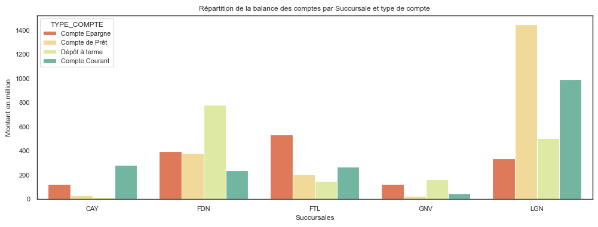

```python
plt.figure(figsize = (12,4))
sns.barplot(x=df.SUCC,y=df.TOTAL_MILLION,data=df,hue="TYPE_COMPTE",palette="Spectral" , estimator=sum).set_title(
    "Répartition de la balance des comptes par Succursale et type de compte");
plt.xlabel("Succursales")
plt.ylabel("Montant en million")
```

### **Répartition des comptes par zone géographique**

```python
query = "SELECT ZONE,count(NOCOMPTE) as QUANTITE from COMPTE group by ZONE"
df = pd.read_sql(query, conn)
df
```

|  | ZONE | QUANTITE |
| --- | --- | --- |
| 0 | SUD | 3851 |
| 1 | NORD | 14236 |
| 2 | OUEST | 11417 |
| 3 | EST | 7423 |

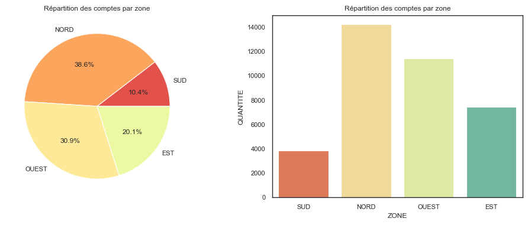

```python
plt.figure(figsize=(12,4))
colors = sns.color_palette("Spectral")
plt.subplot(1,2,1)
plt.pie(df['QUANTITE'], labels=df['ZONE'], autopct='%1.1f%%',colors = colors)
plt.title('Répartition des comptes par zone')

plt.subplot(1,2,2)
sns.set_style("white")
sns.barplot(x='ZONE',y='QUANTITE',data=df,hue="ZONE",palette="Spectral").set_title("Répartition des comptes par zone");
plt.show()
```

### **Répartition des comptes par sexe**

```python
query = "SELECT SEXE_CLIENT,count(NOCOMPTE) as QUANTITE from COMPTE group by SEXE_CLIENT"
df = pd.read_sql(query, conn)
df
```

|  | SEXE_CLIENT | QUANTITE |
| --- | --- | --- |
| 0 | Homme | 16907 |
| 1 | Femme | 20020 |

[figure not shown]

```python
plt.figure(figsize=(12,4))
colors = sns.color_palette("Spectral")
plt.subplot(1,2,1)
plt.pie(df['QUANTITE'], labels=df['SEXE_CLIENT'], autopct='%1.1f%%',colors = colors)
plt.title('Répartition des comptes par zone')

plt.subplot(1,2,2)
sns.set_style("white")
sns.barplot(x='SEXE_CLIENT',y='QUANTITE',data=df,hue="SEXE_CLIENT",palette="Spectral").set_title("Répartition des comptes par zone");
plt.show()
```

### **Répartition des comptes par statut du compte**

```python
query = "SELECT STATUT_COMPTE,count(NOCOMPTE) as QUANTITE from COMPTE group by STATUT_COMPTE"
df = pd.read_sql(query, conn)
df
```

|  | STATUT_COMPTE | QUANTITE |
| --- | --- | --- |
| 0 | Ouvert | 27760 |
| 1 | Dormant | 8503 |
| 2 | No Débit | 453 |
| 3 | Fermé | 211 |

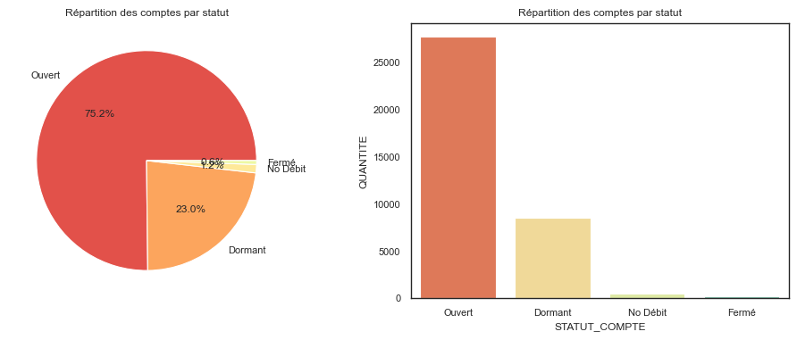

```python
plt.figure(figsize=(12,4))
colors = sns.color_palette("Spectral")
plt.subplot(1,2,1)
plt.pie(df['QUANTITE'], labels=df['STATUT_COMPTE'], autopct='%1.1f%%',colors = colors)
plt.title('Répartition des comptes par statut')

plt.subplot(1,2,2)
sns.set_style("white")
sns.barplot(x='STATUT_COMPTE',y='QUANTITE',data=df,hue="STATUT_COMPTE",palette="Spectral").set_title("Répartition des comptes par statut");
plt.show()
```

### **Répartition des comptes par tranche d'âge**

```python
query = "SELECT RANG_AGE ,count(NOCOMPTE) as QUANTITE from COMPTE group by RANG_AGE"
df = pd.read_sql(query, conn)
df
```

|  | RANG_AGE | QUANTITE |
| --- | --- | --- |
| 0 | Entre 30 & 50 | 8756 |
| 1 | Plus que 70 | 7233 |
| 2 | Entre 50 & 70 | 20938 |

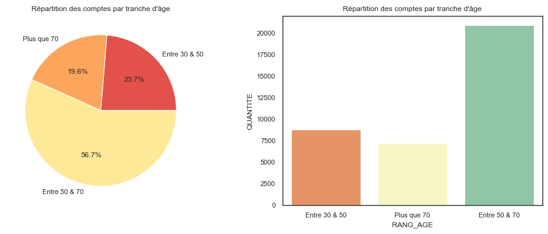

```python
plt.figure(figsize=(12,4))
colors = sns.color_palette("Spectral")
plt.subplot(1,2,1)
plt.pie(df['QUANTITE'], labels=df['RANG_AGE'], autopct='%1.1f%%',colors = colors)
plt.title("Répartition des comptes par tranche d'âge")

plt.subplot(1,2,2)
sns.set_style("white")
sns.barplot(x='RANG_AGE',y='QUANTITE',data=df,hue="RANG_AGE",palette="Spectral").set_title("Répartition des comptes par tranche d'âge");
plt.show()
```

### **Répartition la balance totale des comptes par zône et succursale**

```python
query = """
SELECT ZONE,SUCC, CAST(SUM(BALANCE)/1000000 AS DECIMAL(10,2)) TOTAL_MILLION ,
CAST(SUM(BALANCE)*100/(SELECT SUM(BALANCE) FROM COMPTE) AS DECIMAL(10,2))  AS POURCENTAGE
from COMPTE group by ZONE,SUCC
ORDER BY TOTAL_MILLION
"""
df = pd.read_sql(query, conn)
df
```

|  | ZONE | SUCC | TOTAL_MILLION | POURCENTAGE |
| --- | --- | --- | --- | --- |
| 0 | NORD | GNV | 353.17 | 5.03 |
| 1 | SUD | CAY | 446.39 | 6.36 |
| 2 | NORD | FTL | 1150.62 | 16.38 |
| 3 | EST | FDN | 1793.64 | 25.54 |
| 4 | OUEST | LGN | 3279.48 | 46.69 |

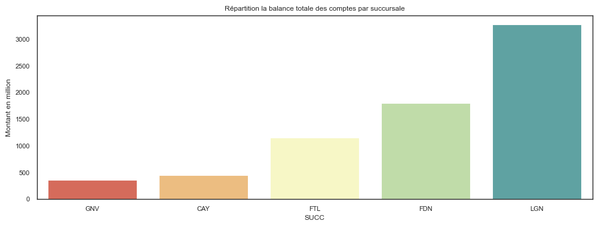

```python
plt.figure(figsize=(12,4))
sns.set_style("white")
sns.barplot(x='SUCC',y='TOTAL_MILLION',data=df,hue="SUCC",palette="Spectral").set_title("Répartition la balance totale des comptes par succursale");
plt.ylabel("Montant en million")
plt.show()
```

### **Répartition la balance totale des comptes par type de compte et succursale**

```python
query = """
SELECT TYPE_COMPTE,SUCC, CAST(SUM(BALANCE)/1000000 AS DECIMAL(10,2)) TOTAL_MILLION,
CAST(SUM(BALANCE)*100/(SELECT SUM(BALANCE) FROM COMPTE) AS DECIMAL(10,2))  AS POURCENTAGE
from COMPTE group by TYPE_COMPTE,SUCC
ORDER BY TOTAL_MILLION
"""
df = pd.read_sql(query, conn)
df
```

|  | TYPE_COMPTE | SUCC | TOTAL_MILLION | POURCENTAGE |
| --- | --- | --- | --- | --- |
| 0 | Dépôt à terme | CAY | 14.81 | 0.21 |
| 1 | Compte de Prêt | GNV | 23.52 | 0.33 |
| 2 | Compte de Prêt | CAY | 28.48 | 0.41 |
| 3 | Compte Courant | GNV | 44.98 | 0.64 |
| 4 | Compte Epargne | CAY | 120.87 | 1.72 |
| 5 | Compte Epargne | GNV | 123.18 | 1.75 |
| 6 | Dépôt à terme | FTL | 147.06 | 2.09 |
| 7 | Dépôt à terme | GNV | 161.50 | 2.30 |
| 8 | Compte de Prêt | FTL | 202.74 | 2.89 |
| 9 | Compte Courant | FDN | 238.48 | 3.40 |
| 10 | Compte Courant | FTL | 268.60 | 3.82 |
| 11 | Compte Courant | CAY | 282.23 | 4.02 |
| 12 | Compte Epargne | LGN | 337.44 | 4.80 |
| 13 | Compte de Prêt | FDN | 379.09 | 5.40 |
| 14 | Compte Epargne | FDN | 395.05 | 5.62 |
| 15 | Dépôt à terme | LGN | 501.25 | 7.14 |
| 16 | Compte Epargne | FTL | 532.21 | 7.58 |
| 17 | Dépôt à terme | FDN | 781.03 | 11.12 |
| 18 | Compte Courant | LGN | 992.80 | 14.14 |
| 19 | Compte de Prêt | LGN | 1448.00 | 20.62 |

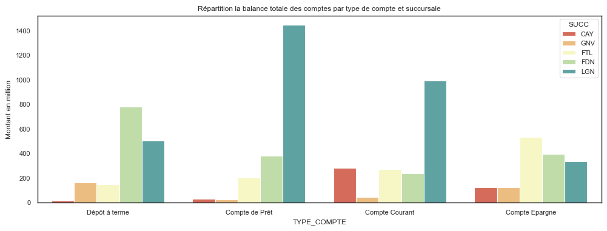

```python
plt.figure(figsize=(12,4))
sns.set_style("white")
sns.barplot(x='TYPE_COMPTE',y='TOTAL_MILLION',data=df,hue="SUCC",palette="Spectral").set_title(
    "Répartition la balance totale des comptes par type de compte et succursale");
plt.ylabel("Montant en million")
plt.show()
```

### **Répartition la balance totale des comptes par zône géographique et type de compte**

```python
query = """
SELECT ZONE, TYPE_COMPTE,CAST(SUM(BALANCE)/1000000 AS DECIMAL(10,2)) TOTAL_MILLION,
CAST(SUM(BALANCE)*100/(SELECT SUM(BALANCE) FROM COMPTE) AS DECIMAL(10,2))  AS POURCENTAGE
from COMPTE group by ZONE,TYPE_COMPTE
ORDER BY TOTAL_MILLION
"""
df = pd.read_sql(query, conn)
df
```

|  | ZONE | TYPE_COMPTE | TOTAL_MILLION | POURCENTAGE |
| --- | --- | --- | --- | --- |
| 0 | SUD | Dépôt à terme | 14.81 | 0.21 |
| 1 | SUD | Compte de Prêt | 28.48 | 0.41 |
| 2 | SUD | Compte Epargne | 120.87 | 1.72 |
| 3 | NORD | Compte de Prêt | 226.25 | 3.22 |
| 4 | EST | Compte Courant | 238.48 | 3.40 |
| 5 | SUD | Compte Courant | 282.23 | 4.02 |
| 6 | NORD | Dépôt à terme | 308.56 | 4.39 |
| 7 | NORD | Compte Courant | 313.58 | 4.46 |
| 8 | OUEST | Compte Epargne | 337.44 | 4.80 |
| 9 | EST | Compte de Prêt | 379.09 | 5.40 |
| 10 | EST | Compte Epargne | 395.05 | 5.62 |
| 11 | OUEST | Dépôt à terme | 501.25 | 7.14 |
| 12 | NORD | Compte Epargne | 655.40 | 9.33 |
| 13 | EST | Dépôt à terme | 781.03 | 11.12 |
| 14 | OUEST | Compte Courant | 992.80 | 14.14 |
| 15 | OUEST | Compte de Prêt | 1448.00 | 20.62 |

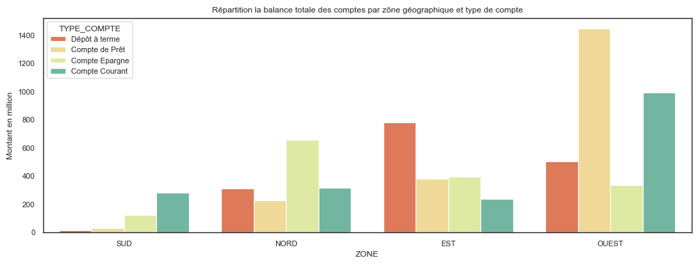

```python
plt.figure(figsize=(12,4))
sns.set_style("white")
sns.barplot(x='ZONE',y='TOTAL_MILLION',data=df,hue="TYPE_COMPTE",palette="Spectral").set_title(
    "Répartition la balance totale des comptes par zône géographique et type de compte");
plt.ylabel("Montant en million")
plt.show()
```

### **Répartition la balance totale des comptes par sexe et type de compte**

```python
query = """
SELECT SEXE_CLIENT,TYPE_COMPTE, CAST(SUM(BALANCE)/1000000 AS DECIMAL(10,2)) TOTAL_MILLION ,
CAST(SUM(BALANCE)*100/(SELECT SUM(BALANCE) FROM COMPTE) AS DECIMAL(10,2))  AS POURCENTAGE
from COMPTE group by SEXE_CLIENT,TYPE_COMPTE
ORDER BY TOTAL_MILLION
"""
df = pd.read_sql(query, conn)
df
```

|  | SEXE_CLIENT | TYPE_COMPTE | TOTAL_MILLION | POURCENTAGE |
| --- | --- | --- | --- | --- |
| 0 | Femme | Dépôt à terme | 410.76 | 5.85 |
| 1 | Femme | Compte Courant | 539.04 | 7.68 |
| 2 | Femme | Compte Epargne | 544.31 | 7.75 |
| 3 | Homme | Compte de Prêt | 811.30 | 11.55 |
| 4 | Homme | Compte Epargne | 964.44 | 13.73 |
| 5 | Homme | Dépôt à terme | 1194.88 | 17.01 |
| 6 | Femme | Compte de Prêt | 1270.52 | 18.09 |
| 7 | Homme | Compte Courant | 1288.05 | 18.34 |

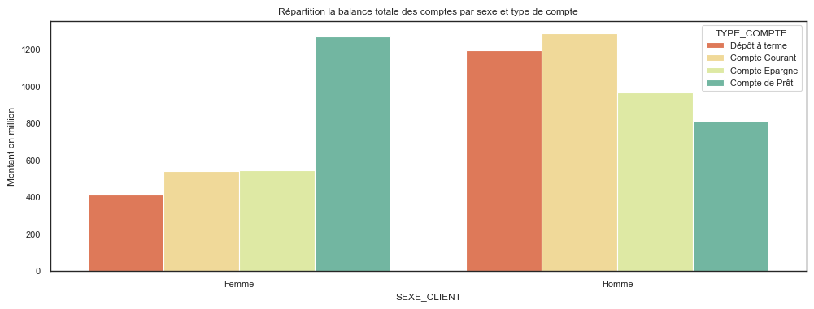

```python
plt.figure(figsize=(12,4))
sns.set_style("white")
sns.barplot(x='SEXE_CLIENT',y='TOTAL_MILLION',data=df,hue="TYPE_COMPTE",palette="Spectral").set_title(
    "Répartition la balance totale des comptes par sexe et type de compte");
plt.ylabel("Montant en million")
plt.show()
```

### **Répartition la balance totale des comptes par type de compte et statut**

```python
query = """
SELECT TYPE_COMPTE, STATUT_COMPTE,CAST(SUM(BALANCE)/1000000 AS DECIMAL(10,2)) TOTAL_MILLION,
CAST(SUM(BALANCE)*100/(SELECT SUM(BALANCE) FROM COMPTE) AS DECIMAL(10,2))  AS POURCENTAGE
from COMPTE group by TYPE_COMPTE,STATUT_COMPTE
ORDER BY TOTAL_MILLION
"""
df = pd.read_sql(query, conn)
df
```

|  | TYPE_COMPTE | STATUT_COMPTE | TOTAL_MILLION | POURCENTAGE |
| --- | --- | --- | --- | --- |
| 0 | Compte Courant | Fermé | 3.41 | 0.05 |
| 1 | Dépôt à terme | No Débit | 19.34 | 0.28 |
| 2 | Compte Courant | No Débit | 28.27 | 0.40 |
| 3 | Compte Epargne | No Débit | 46.41 | 0.66 |
| 4 | Dépôt à terme | Dormant | 107.28 | 1.53 |
| 5 | Compte Courant | Dormant | 196.93 | 2.80 |
| 6 | Compte Epargne | Dormant | 210.42 | 3.00 |
| 7 | Compte Epargne | Ouvert | 1251.92 | 17.83 |
| 8 | Dépôt à terme | Ouvert | 1479.03 | 21.06 |
| 9 | Compte Courant | Ouvert | 1598.49 | 22.76 |
| 10 | Compte de Prêt | Ouvert | 2081.82 | 29.64 |

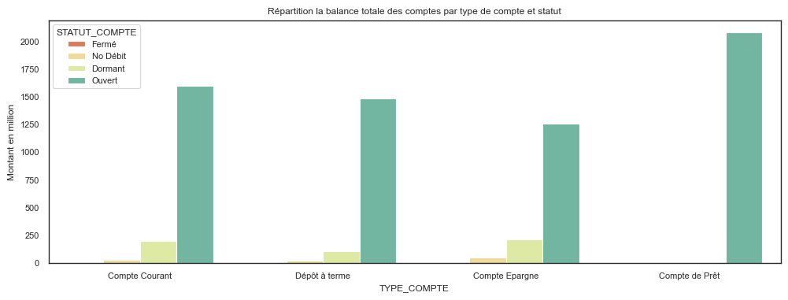

```python
plt.figure(figsize=(12,4))
sns.set_style("white")
sns.barplot(x='TYPE_COMPTE',y='TOTAL_MILLION',data=df,hue="STATUT_COMPTE",palette="Spectral").set_title(
    "Répartition la balance totale des comptes par type de compte et statut");
plt.ylabel("Montant en million")
plt.show()
```

### **Répartition la balance totale des comptes zône et tranche d'âge**

```python
query = """
SELECT ZONE,RANG_AGE, CAST(SUM(BALANCE)/1000000 AS DECIMAL(10,2)) TOTAL_MILLION,
CAST(SUM(BALANCE)*100/(SELECT SUM(BALANCE) FROM COMPTE) AS DECIMAL(10,2))  AS POURCENTAGE
from COMPTE group by ZONE, RANG_AGE
ORDER BY TOTAL_MILLION
"""
df = pd.read_sql(query, conn)
df
```

|  | ZONE | RANG_AGE | TOTAL_MILLION | POURCENTAGE |
| --- | --- | --- | --- | --- |
| 0 | SUD | Plus que 70 | 6.59 | 0.09 |
| 1 | EST | Plus que 70 | 6.67 | 0.09 |
| 2 | NORD | Plus que 70 | 15.73 | 0.22 |
| 3 | OUEST | Plus que 70 | 22.43 | 0.32 |
| 4 | SUD | Entre 50 & 70 | 64.42 | 0.92 |
| 5 | EST | Entre 50 & 70 | 94.06 | 1.34 |
| 6 | NORD | Entre 50 & 70 | 322.97 | 4.60 |
| 7 | OUEST | Entre 50 & 70 | 358.74 | 5.11 |
| 8 | SUD | Entre 30 & 50 | 375.38 | 5.34 |
| 9 | NORD | Entre 30 & 50 | 1165.09 | 16.59 |
| 10 | EST | Entre 30 & 50 | 1692.92 | 24.10 |
| 11 | OUEST | Entre 30 & 50 | 2898.31 | 41.27 |

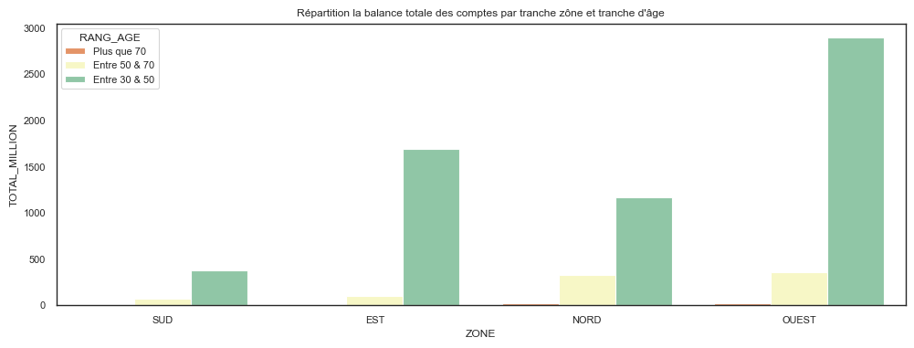

```python
plt.figure(figsize=(12,4))
sns.set_style("white")
sns.barplot(x='ZONE',y='TOTAL_MILLION',data=df,hue="RANG_AGE",palette="Spectral").set_title(
    "Répartition la balance totale des comptes par tranche zône et tranche d'âge");
plt.show()
```

### **Répartition la balance totale par zône, succursale et type de compte**

```python
query = """
SELECT ZONE,SUCC,TYPE_COMPTE, CAST(SUM(BALANCE)/1000000 AS DECIMAL(10,2)) TOTAL_MILLION,
CAST(SUM(BALANCE)*100/(SELECT SUM(BALANCE) FROM COMPTE) AS DECIMAL(10,2))  AS POURCENTAGE
from COMPTE group by ZONE,SUCC,TYPE_COMPTE
ORDER BY ZONE
"""
df = pd.read_sql(query, conn)
df
```

|  | ZONE | SUCC | TYPE_COMPTE | TOTAL_MILLION | POURCENTAGE |
| --- | --- | --- | --- | --- | --- |
| 0 | EST | FDN | Compte Epargne | 395.05 | 5.62 |
| 1 | EST | FDN | Dépôt à terme | 781.03 | 11.12 |
| 2 | EST | FDN | Compte de Prêt | 379.09 | 5.40 |
| 3 | EST | FDN | Compte Courant | 238.48 | 3.40 |
| 4 | NORD | GNV | Compte Epargne | 123.18 | 1.75 |
| 5 | NORD | FTL | Compte Courant | 268.60 | 3.82 |
| 6 | NORD | FTL | Compte de Prêt | 202.74 | 2.89 |
| 7 | NORD | GNV | Dépôt à terme | 161.50 | 2.30 |
| 8 | NORD | FTL | Dépôt à terme | 147.06 | 2.09 |
| 9 | NORD | GNV | Compte de Prêt | 23.52 | 0.33 |
| 10 | NORD | FTL | Compte Epargne | 532.21 | 7.58 |
| 11 | NORD | GNV | Compte Courant | 44.98 | 0.64 |
| 12 | OUEST | LGN | Dépôt à terme | 501.25 | 7.14 |
| 13 | OUEST | LGN | Compte Epargne | 337.44 | 4.80 |
| 14 | OUEST | LGN | Compte Courant | 992.80 | 14.14 |
| 15 | OUEST | LGN | Compte de Prêt | 1448.00 | 20.62 |
| 16 | SUD | CAY | Compte Epargne | 120.87 | 1.72 |
| 17 | SUD | CAY | Compte Courant | 282.23 | 4.02 |
| 18 | SUD | CAY | Dépôt à terme | 14.81 | 0.21 |
| 19 | SUD | CAY | Compte de Prêt | 28.48 | 0.41 |

### **Répartition des comptes par sexe et année de naissance du client**

```python
query = "SELECT ANNEE,SEXE_CLIENT, COUNT(NOCOMPTE) QUANTITE from COMPTE group by ANNEE,SEXE_CLIENT ORDER BY ANNEE"
df = pd.read_sql(query, conn)
df
```

|  | ANNEE | SEXE_CLIENT | QUANTITE |
| --- | --- | --- | --- |
| 0 | 1942 | Femme | 28 |
| 1 | 1942 | Homme | 44 |
| 2 | 1943 | Homme | 84 |
| 3 | 1943 | Femme | 51 |
| 4 | 1944 | Homme | 88 |
| ... | ... | ... | ... |
| 83 | 1983 | Homme | 432 |
| 84 | 1984 | Homme | 372 |
| 85 | 1984 | Femme | 161 |
| 86 | 1985 | Homme | 293 |
| 87 | 1985 | Femme | 64 |

88 rows × 3 columns

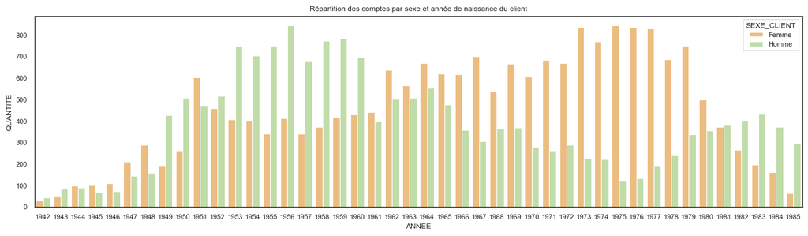

```python
plt.figure(figsize=(16,4))
data=df
sns.set_style("white")
sns.barplot(x="ANNEE",y="QUANTITE",data=data,palette="Spectral",hue="SEXE_CLIENT").set_title(
    "Répartition des comptes par sexe et année de naissance du client");
plt.show()
```

### **Afficher les 5 plus grands clients par produit**

```python
query = """
	WITH CTE AS
	(
	SELECT TYPE_COMPTE,NUMERO, CAST(SUM(BALANCE)/1000000 AS DECIMAL(10,2)) TOTAL_MILLION,
	RANK() OVER( PARTITION BY TYPE_COMPTE ORDER BY CAST(SUM(BALANCE)/1000000 AS DECIMAL(10,2)) DESC) AS RANG from COMPTE
	GROUP BY TYPE_COMPTE,NUMERO)
	SELECT * FROM CTE WHERE RANG<=5 ORDER BY TYPE_COMPTE
"""

df = pd.read_sql(query, conn)
df
```

|  | TYPE_COMPTE | NUMERO | TOTAL_MILLION | RANG |
| --- | --- | --- | --- | --- |
| 0 | Compte Courant | 387277 | 30.01 | 1 |
| 1 | Compte Courant | 797017 | 27.45 | 2 |
| 2 | Compte Courant | 810018 | 24.76 | 3 |
| 3 | Compte Courant | 87151 | 24.08 | 4 |
| 4 | Compte Courant | 412932 | 23.01 | 5 |
| 5 | Compte de Prêt | 89436 | 25.87 | 1 |
| 6 | Compte de Prêt | 89434 | 24.08 | 2 |
| 7 | Compte de Prêt | 89432 | 21.35 | 3 |
| 8 | Compte de Prêt | 89430 | 20.93 | 4 |
| 9 | Compte de Prêt | 89425 | 19.48 | 5 |
| 10 | Compte Epargne | 543318 | 14.45 | 1 |
| 11 | Compte Epargne | 194212 | 13.08 | 2 |
| 12 | Compte Epargne | 148969 | 12.70 | 3 |
| 13 | Compte Epargne | 928944 | 11.59 | 4 |
| 14 | Compte Epargne | 526328 | 11.32 | 5 |
| 15 | Dépôt à terme | 92507 | 21.95 | 1 |
| 16 | Dépôt à terme | 92617 | 20.00 | 2 |
| 17 | Dépôt à terme | 91673 | 20.00 | 2 |
| 18 | Dépôt à terme | 16081 | 18.68 | 4 |
| 19 | Dépôt à terme | 32159 | 18.11 | 5 |

### **Afficher les 2 plus grands clients par Succursale**

```python
query = """
	WITH CTE AS
	(
	SELECT SUCC,NUMERO, CAST(SUM(BALANCE)/1000000 AS DECIMAL(10,2)) TOTAL_MILLION,
	RANK() OVER( PARTITION BY SUCC ORDER BY CAST(SUM(BALANCE)/1000000 AS DECIMAL(10,2)) DESC) AS RANG from COMPTE
	GROUP BY SUCC,NUMERO)
	SELECT * FROM CTE WHERE RANG<=2 ORDER BY SUCC
"""

df = pd.read_sql(query, conn)
df
```

|  | SUCC | NUMERO | TOTAL_MILLION | RANG |
| --- | --- | --- | --- | --- |
| 0 | CAY | 84115 | 15.71 | 1 |
| 1 | CAY | 85865 | 11.18 | 2 |
| 2 | FDN | 797017 | 27.45 | 1 |
| 3 | FDN | 92507 | 21.95 | 2 |
| 4 | FTL | 810018 | 24.76 | 1 |
| 5 | FTL | 92617 | 20.00 | 2 |
| 6 | GNV | 50346 | 19.42 | 1 |
| 7 | GNV | 66215 | 13.93 | 2 |
| 8 | LGN | 387277 | 30.01 | 1 |
| 9 | LGN | 89436 | 25.87 | 2 |

### **Visualisation des données avec MS Excel**

### **Connexion de MS Excel avec MS SQL Server à traver Power Query**

[figure not shown]

### **Importation des données de MS SQL Server**

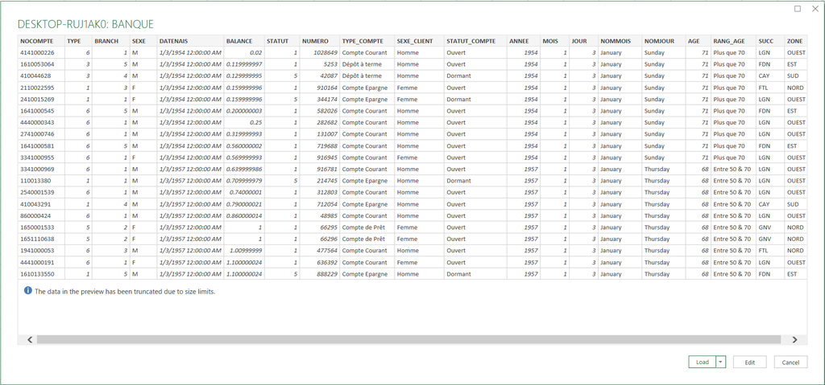

### **Nettoyage des données**

- Conversion des données recuperées en table de données
- Determiniation du type de données approprié pour chaque colonne
- Verification de l'absence de doublon
- verification de l'absence de valeur manquante

### **Modelisation des données**

### **Ajout d'une colonne "MOIS_ABREG"**

- MOIS_ABREG=TEXT([@DATENAIS],"mmm")

### **Ajout d'une colonne "JOUR_ABREG"**

- JOUR_ABREG=TEXT([@DATENAIS],"ddd")

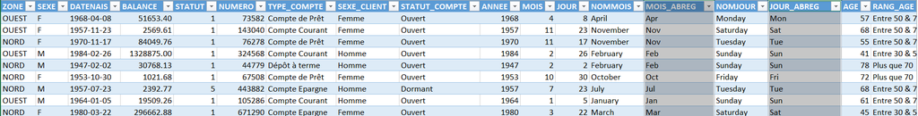

### **Analyse et Visualisation des données**

### **Définition des indicateurs de performance**

Les KPIs requis sont les suivants:

[figure not shown]

### **Définition des graphiques exigés**

Les graphiques requis sont les suivants:

#### **Répartition des comptes par produit**

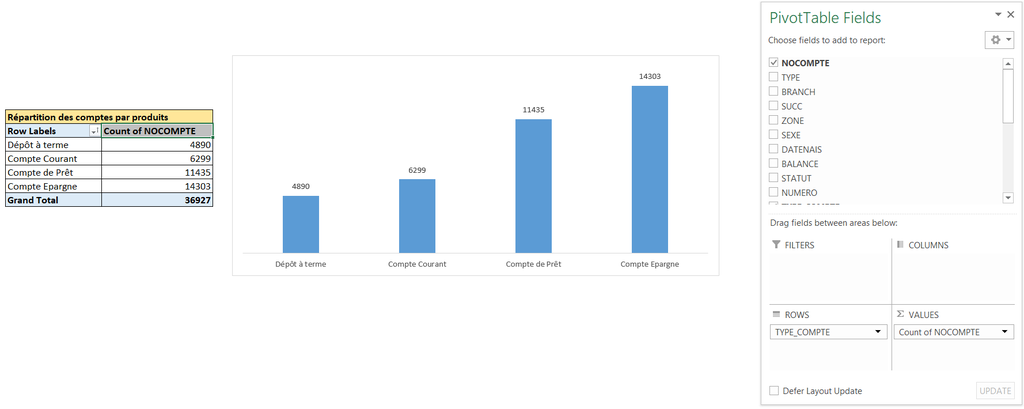

#### **Répartition des comptes par groupe d’âge**

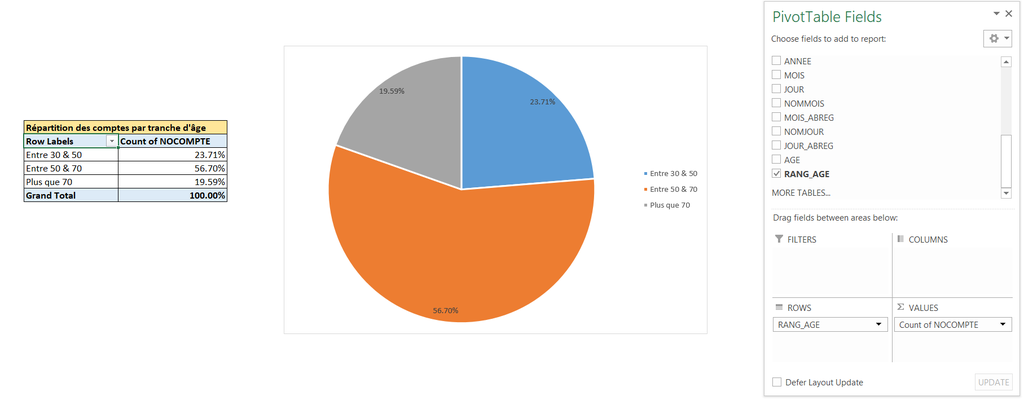

#### **Répartition des comptes par Succursale**

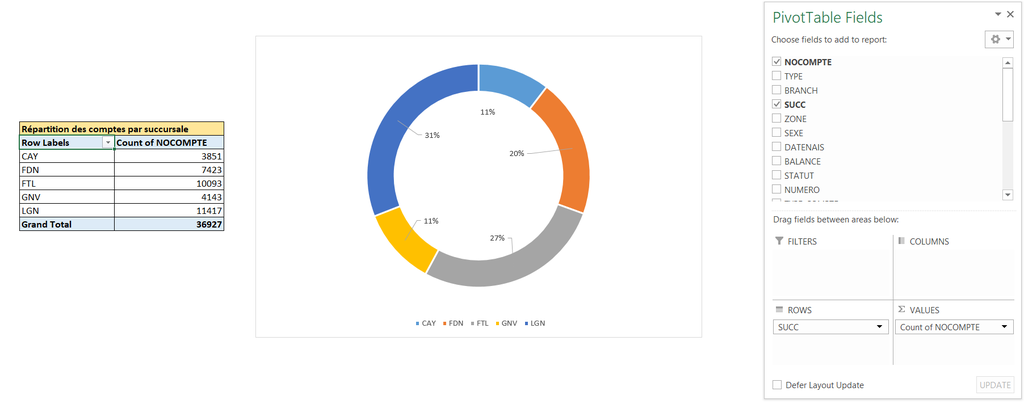

#### **Répartition de la balance par Succursale**

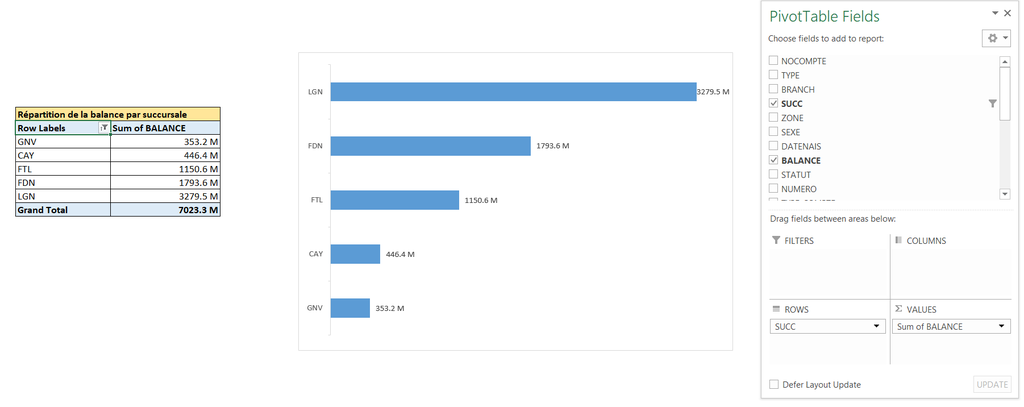

#### **Répartition des comptes par produit et genre**

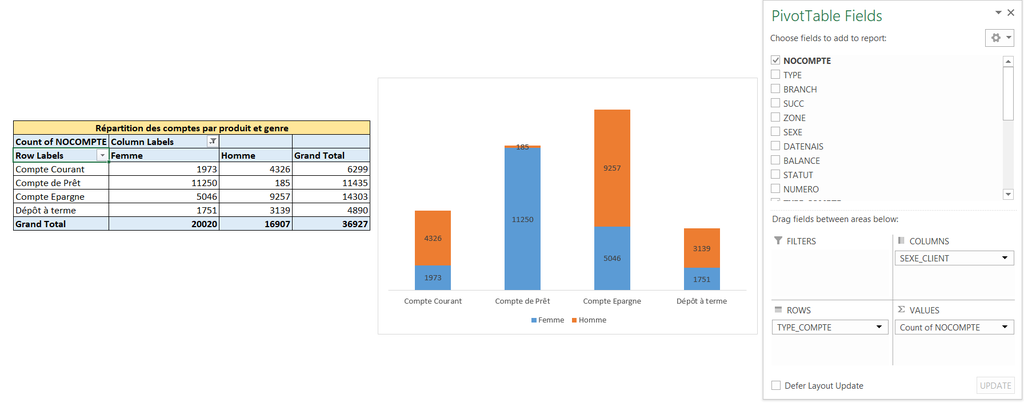

#### **Répartition des comptes par produit et statut**

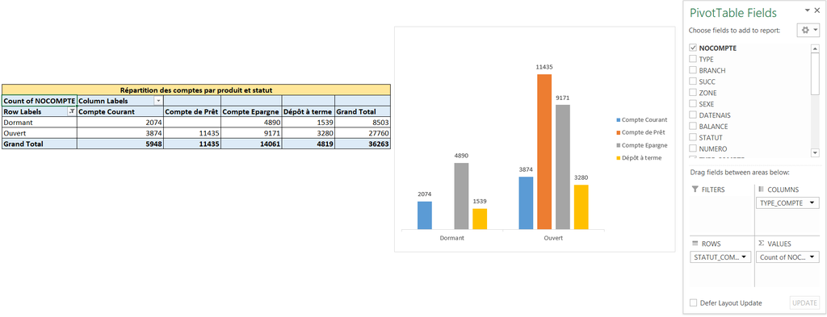

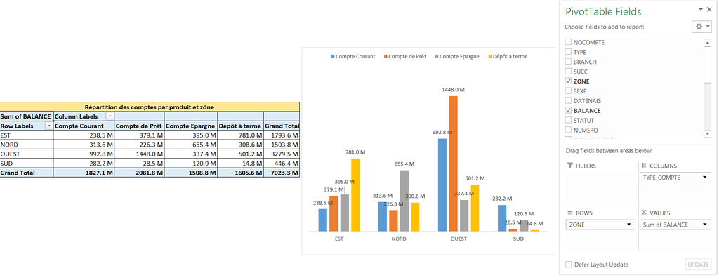

#### **Top cinq grands clients**

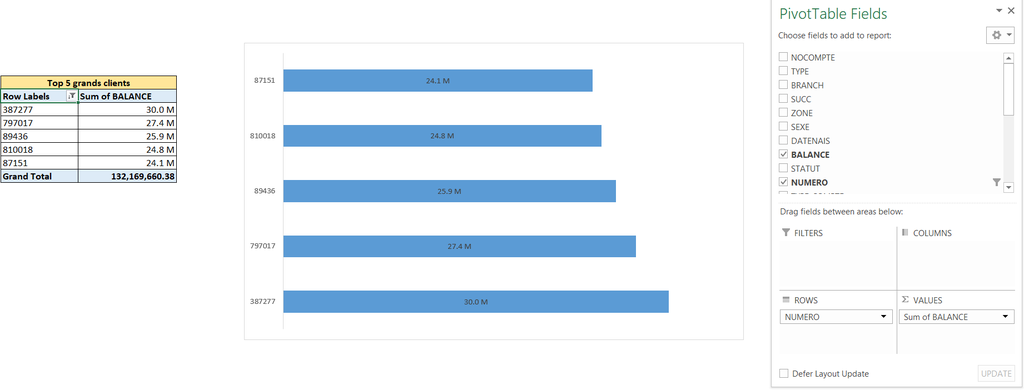

### **Création du tableau de bord avec MS Excel**

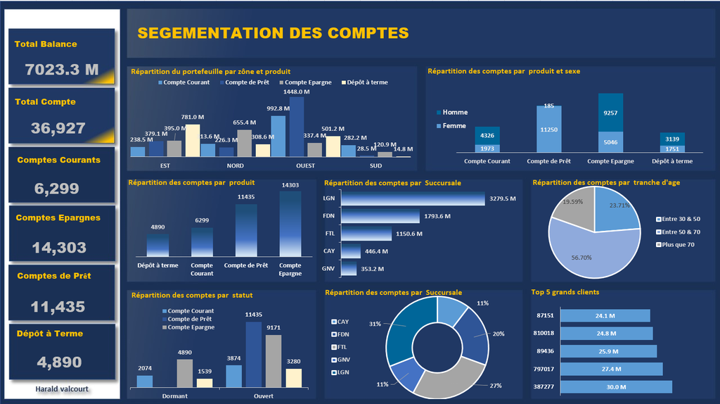

## **Interface de Segmentation des Clients**

[figure not shown]

### **Fonctionnalités**

- Générer des rapports de segmentation de la clientèle selon les critères suivants
  - la nature des comptes
  - la catégorie des comptes
  - la tranche de balance des comptes
  - la Succursale des comptes
  - le statut des comptes
  - la tranche d’âge des clients
  - le sexe du client
  - le statut matrimonial des clients
  - le département d'habitation des clients
  - Le secteur d'activité des clients
  - La profession des clients
- Générer des rapports ciblés en fonction de différents critères variables
  - La monnaie des comptes
  - La nature des comptes
  - La Succursale des comptes
  - La tranche de balance des comptes
  - La tranche d’âge des clients
- Générer les rapports du portefeuille pour tous les types de comptes
- Générer le rapport des grands clients pour une Succursale désignée
- Générer le rapport de tous les grands clients de dépôt
- Générer le rapport de tous les grands clients de placement
- Générer le rapport des grands clients de prêt

### **Jeu de données**

Il est important de souligner que les statistiques présentées dans cette présentation n’ont rien à voir avec la réalité. Les requêtes sont en effet paramétrées.

### **Rapports de segmentation selon la nature des comptes générés automatiquement**

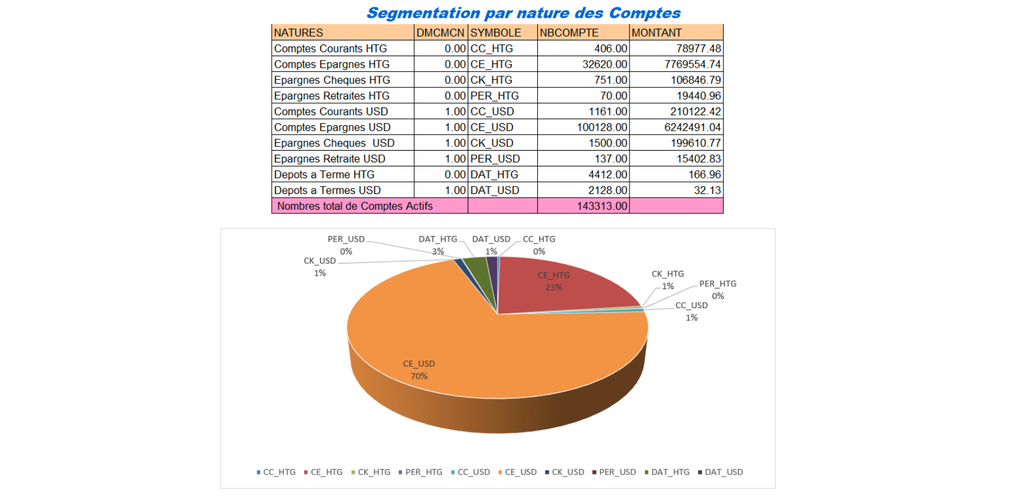

[figure not shown]

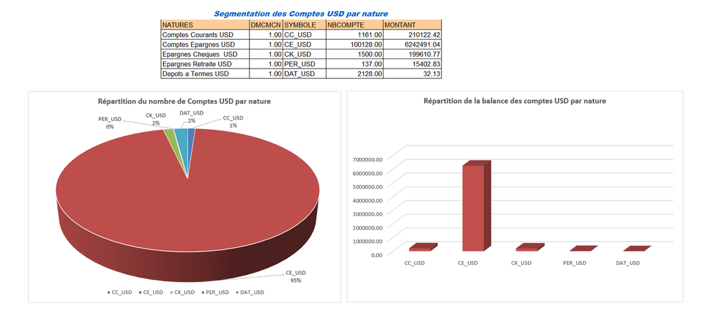